# NYPD Shooting Incident Data Report

MSDS-Student

2024-07-08

```r
library(ggplot2)
library(lubridate)
library(tidyverse)
```

# Assignment - Task 1

## Import, tidy and analyze the NYPD Shooting Incident dataset obtained.

### Import Data

```r
url <- "https://data.cityofnewyork.us/api/views/833y-fsy8/rows.csv"
shootings <- read_csv(url)
```

### Tidy up data

```r
shootings <- shootings %>%
  select(-c(PRECINCT,JURISDICTION_CODE,LOCATION_DESC,X_COORD_CD,Y_COORD_CD,Latitude, Longitude, Lon_Lat, LOC_OF_OCCUR_DESC, LOC_CLASSFCTN_DESC, INCIDENT_KEY))
```

```r
shootings <- shootings %>%
  mutate(OCCUR_DATE = mdy(OCCUR_DATE))
```

```r
shootings$BORO <- factor(shootings$BORO)
shootings$PERP_AGE_GROUP <- factor(shootings$PERP_AGE_GROUP)
shootings$PERP_SEX <- factor(shootings$PERP_SEX)
shootings$PERP_RACE <- factor(shootings$PERP_RACE)
shootings$VIC_AGE_GROUP <- factor(shootings$VIC_AGE_GROUP)
shootings$VIC_SEX <- factor(shootings$VIC_SEX)
shootings$VIC_RACE <- factor(shootings$VIC_RACE)
shootings$STATISTICAL_MURDER_FLAG <- factor(shootings$STATISTICAL_MURDER_FLAG)
```

### Summary of Data

```r
summary(shootings)
```

```
##    OCCUR_DATE          OCCUR_TIME                  BORO
##  Min.   :2006-01-01   Length:28562      BRONX        : 8376
##  1st Qu.:2009-09-04   Class1:hms        BROOKLYN     :11346
##  Median :2013-09-20   Class2:difftime   MANHATTAN    : 3762
##  Mean   :2014-06-07   Mode  :numeric    QUEENS       : 4271
##  3rd Qu.:2019-09-29                     STATEN ISLAND:  807
##  Max.   :2023-12-29
##
##  STATISTICAL_MURDER_FLAG PERP_AGE_GROUP   PERP_SEX              PERP_RACE
##  FALSE:23036             18-24  :6438   (null): 1141   BLACK         :11903
##  TRUE : 5526             25-44  :6041   F     :  444   WHITE HISPANIC: 2510
##                          UNKNOWN:3148   M     :16168   UNKNOWN       : 1837
##                          <18    :1682   U     : 1499   BLACK HISPANIC: 1392
##                          (null) :1141   NA's  : 9310   (null)        : 1141
##                          (Other): 768                  (Other)       :  469
##                          NA's   :9344                  NA's          : 9310
##  VIC_AGE_GROUP   VIC_SEX                             VIC_RACE
##  <18    : 2954   F: 2760   AMERICAN INDIAN/ALASKAN NATIVE:   11
##  1022   :    1   M:25790   ASIAN / PACIFIC ISLANDER      :  440
##  18-24  :10384   U:   12   BLACK                         :20235
##  25-44  :12973             BLACK HISPANIC                : 2795
##  45-64  : 1981             UNKNOWN                       :   70
##  65+    :  205             WHITE                         :  728
##  UNKNOWN:   64             WHITE HISPANIC                : 4283
```

# Assignment - Task 2

## Be sure your project is reproducible and contains some visualization and analysis. You may use the data to do any analysis that is of interest to you. You may use the data to do any analysis that is of interest to you. You should include at least two visualizations and one model.

### Project is reproducible as we have the analysis and visualization done on R

### Visualizations Alanysis 1 - I would like to analyze fatal and non fatal victims age-group

#### From the charts below we can confirm that the data is close to complete as UNKNOWN age group data is almost negligible.

#### We can say with confidence that majority of the victims are in age group 18-44 is both fatal and non fatal incidents.

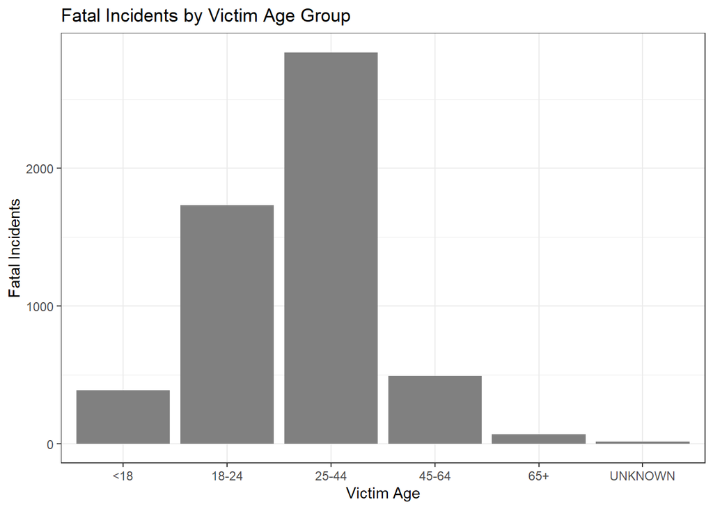

```r
shootings %>%
  filter(STATISTICAL_MURDER_FLAG == TRUE) %>%
  ggplot(aes(x = VIC_AGE_GROUP)) +
  geom_bar(fill = "#808080")+
  theme_bw()+
  labs(x = "Victim Age",
       y = "Fatal Incidents",
       title = "Fatal Incidents by Victim Age Group")
```

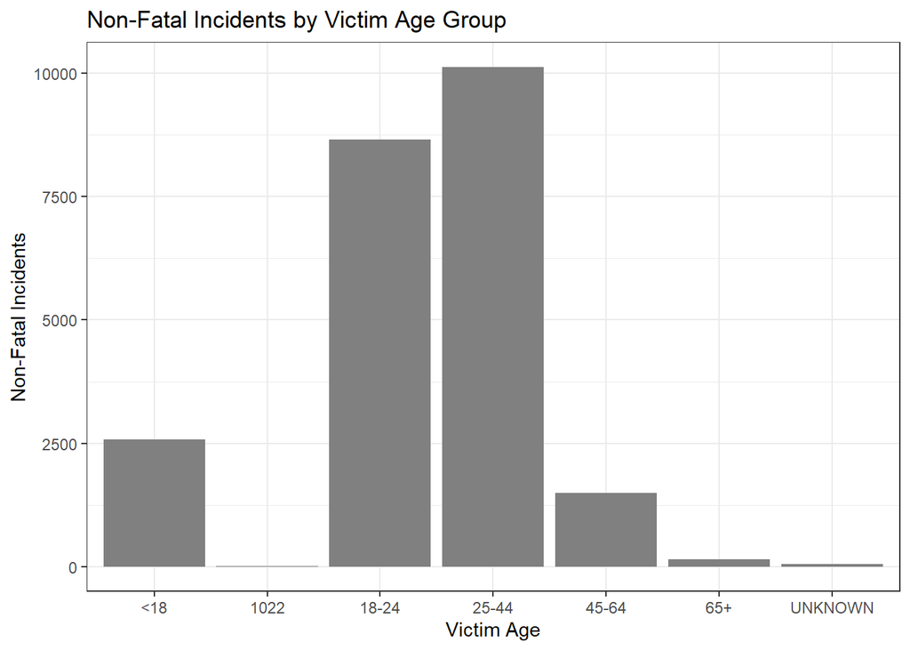

```r
shootings %>%
  filter(STATISTICAL_MURDER_FLAG == FALSE) %>%
  ggplot(aes(x = VIC_AGE_GROUP)) +
  geom_bar(fill = "#808080")+
  theme_bw()+
  labs(x = "Victim Age",
       y = "Non-Fatal Incidents",
       title = "Non-Fatal Incidents by Victim Age Group")
```

### Visualization Analysis 2 - I would like to analyze the gender of most affected victims

#### From the charts below we can confirm that the data is close to complete as UNKNOWN gender data is almost negligible.

#### We can say with confidence that majority of the victims are male.

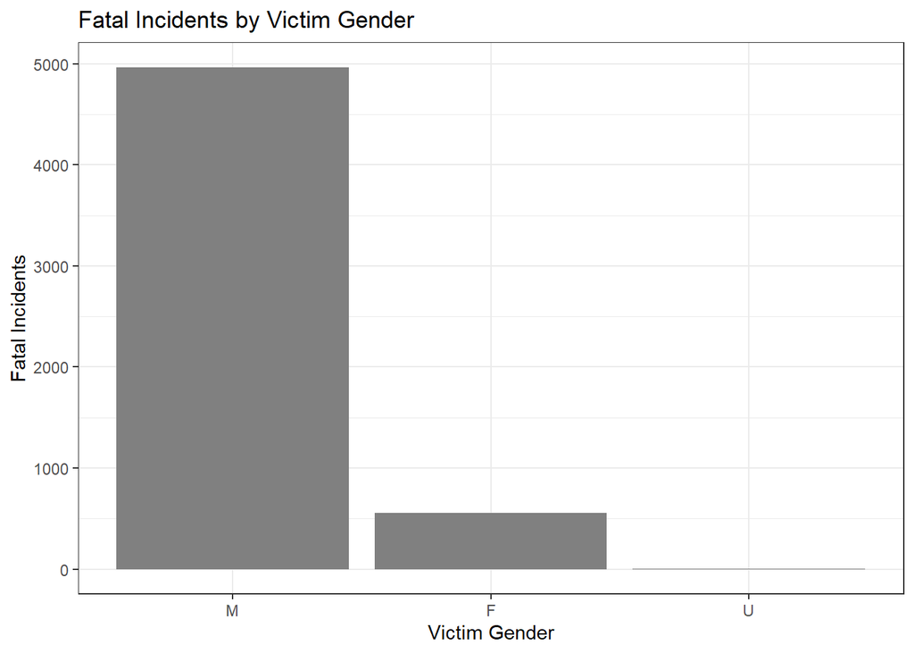

```r
shootings %>%
  filter(STATISTICAL_MURDER_FLAG == TRUE) %>%
  ggplot(aes(x = fct_infreq(VIC_SEX))) +
  geom_bar(stat = 'count')+
  geom_bar(fill = "#808080")+
  theme_bw()+
  labs(x = "Victim Gender",
       y = "Fatal Incidents",
       title = "Fatal Incidents by Victim Gender")
```

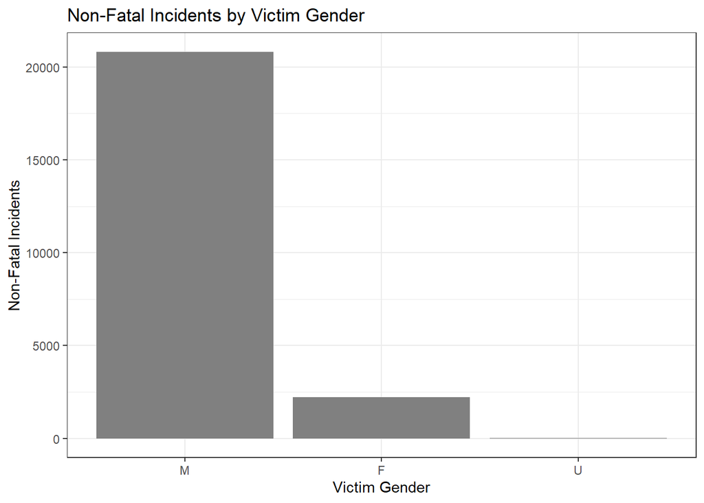

```r
shootings %>%
    filter(STATISTICAL_MURDER_FLAG == FALSE) %>%
  ggplot(aes(x = fct_infreq(VIC_SEX))) +
  geom_bar(stat = 'count')+
  geom_bar(fill = "#808080")+
  theme_bw()+
  labs(x = "Victim Gender",
       y = "Non-Fatal Incidents",
       title = "Non-Fatal Incidents by Victim Gender")
```

### Model Analysis 3 - I would analyze data from model if Fatal Incident is linked to victims age, gender etc.

```
##
## Call:
## glm(formula = STATISTICAL_MURDER_FLAG ~ VIC_AGE_GROUP + VIC_RACE +
##     VIC_SEX, family = "binomial", data = shootings)
##
## Coefficients:
##                                   Estimate Std. Error z value Pr(>|z|)
## (Intercept)                      -12.90411   97.39229  -0.132   0.8946
## VIC_AGE_GROUP1022                -10.66158  324.74370  -0.033   0.9738
## VIC_AGE_GROUP18-24                 0.28445    0.06081   4.678 2.90e-06 ***
## VIC_AGE_GROUP25-44                 0.61495    0.05880  10.458  < 2e-16 ***
## VIC_AGE_GROUP45-64                 0.75645    0.07591   9.965  < 2e-16 ***
## VIC_AGE_GROUP65+                   1.08054    0.16030   6.741 1.58e-11 ***
## VIC_AGE_GROUPUNKNOWN               0.86260    0.31637   2.727   0.0064 **
## VIC_RACEASIAN / PACIFIC ISLANDER  11.29529   97.39233   0.116   0.9077
## VIC_RACEBLACK                     11.03210   97.39227   0.113   0.9098
## VIC_RACEBLACK HISPANIC            10.86233   97.39228   0.112   0.9112
## VIC_RACEUNKNOWN                   10.21286   97.39317   0.105   0.9165
## VIC_RACEWHITE                     11.34597   97.39230   0.116   0.9073
## VIC_RACEWHITE HISPANIC            11.13984   97.39227   0.114   0.9089
## VIC_SEXM                          -0.03247    0.05080  -0.639   0.5227
## VIC_SEXU                          -0.61990    1.08054  -0.574   0.5662
## ---
## Signif. codes:  0 '***' 0.001 '**' 0.01 '*' 0.05 '.' 0.1 ' ' 1
##
## (Dispersion parameter for binomial family taken to be 1)
##
##     Null deviance: 28061  on 28561  degrees of freedom
## Residual deviance: 27772  on 28547  degrees of freedom
## AIC: 27802
##
## Number of Fisher Scoring iterations: 11
```

# Assignment - Task 3

## Be sure to identify any bias possible in the data and in your analysis.

### Without any bias and stricly following the data, we can conclude that in NY victims and perpetrators are mostly men.